# Prerequisite Test

```python
%pip install jax jaxlib
```

```python
import matplotlib.pyplot as plt
import numpy as np
import math
import pandas as pd
import sympy as sp
import jax
import jax.numpy as jnp
import random
```

### Questions

1. How many multiplications and additions do you need to perform a matrix multiplication between a (n, k) and (k, m) matrix? Explain.

To multiply a matrix **A** of shape $(n, k)$ and a matrix **B** of shape $(k, m)$, we produce a resulting matrix **C** of shape $(n, m)$.

Let's consider how a single element $C_{ij}$ (the element in the $i$-th row and $j$-th column) of the resulting matrix is calculated. It's the dot product of the $i$-th row of **A** and the $j$-th column of **B**.

$$ C_{ij} = \sum_{p=1}^{k} A_{ip} \times B_{pj} $$

To calculate this single element $C_{ij}$:

- **Multiplications**: We perform $k$ multiplications (one for each term $A_{ip} \times B_{pj}$).
- **Additions**: We perform $k-1$ additions to sum the $k$ products.

Since the resulting matrix **C** has $n \times m$ elements, we can find the total number of operations:

- **Total Multiplications**: $(n \times m) \times k = nmk$
- **Total Additions**: $(n \times m) \times (k-1) = nm(k-1)$

So, you need **$nmk$ multiplications** and **$nm(k-1)$ additions** to perform the matrix multiplication.

2. Write Python code to multiply the above two matrices. Solve using list of lists and then use numpy. Compare the timing of both solutions. Which one is faster? Why?

```python
import time
n, k, m = 100, 200, 150 # Define matrix dimensions

def multiply_list_of_lists(A, B):

    n, k1 = len(A), len(A[0])
    k2, m = len(B), len(B[0])

    if k1 != k2:
        raise ValueError("Incompatible matrix dimensions for multiplication")

    C = [[0 for _ in range(m)] for _ in range(n)]  # result matrix with zeros

    for i in range(n):   # multiplication
        for j in range(m):
            for p in range(k1):
                C[i][j] += A[i][p] * B[p][j]
    return C

#  using NumPy
def multiply_numpy(A, B):
    return np.dot(A, B)
list_A = [[np.random.rand() for _ in range(k)] for _ in range(n)]
list_B = [[np.random.rand() for _ in range(m)] for _ in range(k)]
numpy_A = np.array(list_A)
numpy_B = np.array(list_B)

# Time the list of lists implementation
start_time_list = time.time()
result_list = multiply_list_of_lists(list_A, list_B)
end_time_list = time.time()
print(f"List of lists time: {end_time_list - start_time_list:.6f} seconds")

# Time the NumPy implementation
start_time_numpy = time.time()
result_numpy = multiply_numpy(numpy_A, numpy_B)
end_time_numpy = time.time()
print(f"NumPy time: {end_time_numpy - start_time_numpy:.6f} seconds")
```

```
List of lists time: 0.298910 seconds
NumPy time: 0.008391 seconds
```

3. Finding the highest element in a list requires one pass of the array. Finding the second highest element requires 2 passes of the array. Using this method, what is the time complexity of finding the median of the array? Can you suggest a better method? Can you implement both these methods in Python and compare against numpy.median routine in terms of time?

The method described in the prompt is an inefficient way to find the median. Finding the $k$-th highest element by performing $k$ passes would lead to a very slow algorithm. To find the median of an array of size $n$, you'd need to find the $(\frac{n}{2})$-th element, requiring approximately $\frac{n}{2}$ passes. Each pass takes $O(n)$ time, so the total time complexity would be $O(\frac{n}{2} \times n) = \boldsymbol{O(n^2)}$.

A **better method** is to sort the array first. Sorting an array of size $n$ typically takes $\boldsymbol{O(n \log n)}$ time. After sorting, the median can be found in $O(1)$ time by simply selecting the middle element. This is much more efficient than the $O(n^2)$ approach.

An **even more optimal algorithm** for this specific problem (finding the k-th smallest element) is a selection algorithm like **Quickselect**, which has an average time complexity of $\boldsymbol{O(n)}$. NumPy's median function is highly optimized and likely uses such an algorithm.

```python
# Method 1: Iterative search (O(n^2) approach)
# This is a simplified interpretation of the "n-pass" method
def find_median_slow(arr):
    n = len(arr)
    temp_arr = list(arr)
    for i in range(n // 2 + 1):
        min_val = temp_arr[i]
        min_idx = i
        for j in range(i + 1, n):
            if temp_arr[j] < min_val:
                min_val = temp_arr[j]
                min_idx = j
        temp_arr[i], temp_arr[min_idx] = temp_arr[min_idx], temp_arr[i]
    return temp_arr[n // 2] if n % 2 != 0 else (temp_arr[n // 2 - 1] + temp_arr[n // 2]) / 2


# Method 2: Sorting (O(n log n) approach)
def find_median_sorting(arr):
    sorted_arr = sorted(arr)
    n = len(sorted_arr)
    mid = n // 2
    if n % 2 == 1:
        return sorted_arr[mid]
    else:
        return (sorted_arr[mid - 1] + sorted_arr[mid]) / 2

test_data = [random.randint(0, 10000) for _ in range(5000)] # Create a large random list
numpy_data = np.array(test_data)

start_time = time.time() # Time the slow method
median_slow = find_median_slow(test_data)
end_time = time.time()
print(f"O(n^2) method time: {end_time - start_time:.6f} seconds. Median: {median_slow}")

start_time = time.time() # Time the sorting method
median_sorting = find_median_sorting(test_data)
end_time = time.time()
print(f"O(n log n) method time: {end_time - start_time:.6f} seconds. Median: {median_sorting}")

start_time = time.time() # Time the NumPy method
median_numpy = np.median(numpy_data)
end_time = time.time()
print(f"NumPy method time: {end_time - start_time:.6f} seconds. Median: {median_numpy}")
```

```
O(n^2) method time: 0.380068 seconds. Median: 5004.5
O(n log n) method time: 0.000000 seconds. Median: 5004.5
NumPy method time: 0.037860 seconds. Median: 5004.5
```

4. What is the gradient of the following function with respect to x and y?

$x^2y + y^3sin(x)$

The function is $f(x,y)=x^2y + y^3sin(x)$

The gradient of a function is a vector that contains all of its partial derivatives. For the function $f(x,y)=x^2y + y^3sin(x)$, we need to compute the partial derivatives with respect to x and y. The partial derivative with respect to x is: $$\frac{\partial f}{\partial x} = 2xy + y^3cos(x)$$ The partial derivative with respect to y is: $$\frac{\partial f}{\partial y} = x^2 + 3y^2sin(x)$$

The gradient of f(x,y), denoted as ∇f, is the vector: ∇f(x,y) = $[∂f/∂x, ∂f/∂y] = [2xy + y^3cos(x), x^2 + 3y^2sin(x)]$

5. Use JAX to confirm the gradient evaluated by your method matches the analytical solution corresponding to a few random values of x and y

```python
# JAX
def f(x, y):
    return x**2 * y + y**3 * jnp.sin(x)

grad_f_jax = jax.grad(f, argnums=(0, 1))

def grad_f_analytical(x, y):    # gradient function
    df_dx = 2 * x * y + y**3 * np.cos(x)
    df_dy = x**2 + 3 * y**2 * np.sin(x)
    return df_dx, df_dy

# Test with a few random values
key = jax.random.PRNGKey(0)
for _ in range(3):
    # Generate random floats for x and y
    rand_x, rand_y = jax.random.uniform(key, (2,))
    key, _ = jax.random.split(key)

    # Evaluate gradients
    jax_grad_x, jax_grad_y = grad_f_jax(rand_x, rand_y)
    analytical_grad_x, analytical_grad_y = grad_f_analytical(float(rand_x), float(rand_y))

    print(f"\nTesting for x={rand_x:.4f}, y={rand_y:.4f}")
    print(f"JAX gradient:      df/dx={jax_grad_x:.4f}, df/dy={jax_grad_y:.4f}")
    print(f"Analytical gradient: df/dx={analytical_grad_x:.4f}, df/dy={analytical_grad_y:.4f}")

    # Confirm they are nearly equal
    assert np.allclose(jax_grad_x, analytical_grad_x)
    assert np.allclose(jax_grad_y, analytical_grad_y)
```

```
Testing for x=0.9477, y=0.9786
JAX gradient:      df/dx=2.4016, df/dy=3.2310
Analytical gradient: df/dx=2.4016, df/dy=3.2310

Testing for x=0.8423, y=0.1824
JAX gradient:      df/dx=0.3113, df/dy=0.7840
Analytical gradient: df/dx=0.3113, df/dy=0.7840

Testing for x=0.2827, y=0.7881
JAX gradient:      df/dx=0.9157, df/dy=0.5997
Analytical gradient: df/dx=0.9157, df/dy=0.5997
```

6. Use sympy to confirm that you obtain the same gradient analytically.

```python
x, y = sp.symbols('x y')
expr = x**2 * y + y**3 * sp.sin(x)
df_dx = sp.diff(expr, x)
print(f"SymPy df/dx: {df_dx}")
df_dy = sp.diff(expr, y)
print(f"SymPy df/dy: {df_dy}")
```

```
SymPy df/dx: 2*x*y + y**3*cos(x)
SymPy df/dy: x**2 + 3*y**2*sin(x)
```

7. Create a Python nested dictionary to represent hierarchical information. We want to store record of students and their marks. Something like

   2022
   1. Branch 1 Roll Number: 1, Name: N, Marks: Maths: 100, English: 70, …
   2. Branch 2

   2023
   1. Branch 1
   2. Branch 2

   2024
   1. Branch 1
   2. Branch 2

   2025
   1. Branch 1
   2. Branch 2

```python
dict = {
    2022 : {
        "Branch 1" : [
            {"Roll Number: ":1, "Name" : "N", "Marks" : {"Maths" : 100, "English" : 70}},
            {"Roll Number: ":2, "Name" : "A", "Marks" : {"Maths" : 90, "English" : 80}}],
        "Branch 2" : []
    },
    2023 : {
        "Branch 1" : [],
        "Branch 2" : []
        },
    2024 : {
        "Branch 1" : [],
        "Branch 2" : []
},
    2025 : {
        "Branch 1" : [],
        "Branch 2" : []
}}
```

8. Store the same information using Python classes. We have an overall database which is a list of year objects. Each year contains a list of branches. Each branch contains a list of students. Each student has some properties like name, roll number and has marks in some subjects.

```python
class Student:
    def __init__(self, roll_number, name, marks):
        self.roll_number = roll_number
        self.name = name
        self.marks = marks

class Branch:
    def __init__(self, name):
        self.name = name
        self.students = []

    def add_student(self, student):
        self.students.append(student)

class Year:
    def __init__(self, year_value):
        self.year = year_value
        self.branches = {}

    def add_branch(self, branch):
        self.branches[branch.name] = branch

class StudentDatabase:
    def __init__(self):
        self.years = {}

    def add_year(self, year):
        self.years[year.year] = year

db = StudentDatabase()


year_2022 = Year(2022)
db.add_year(year_2022)

branch1_2022 = Branch("Branch 1")
year_2022.add_branch(branch1_2022)

student1 = Student(1, "Student A", {"Maths": 100, "English": 70})
student2 = Student(2, "Student B", {"Maths": 88, "English": 91})
branch1_2022.add_student(student1)
branch1_2022.add_student(student2)

# Example: Accessing data
student_A_maths_class = db.years[2022].branches["Branch 1"].students[0].marks["Maths"]
print(f"Student A's Math score (from classes): {student_A_maths_class}")
```

```
Student A's Math score (from classes): 100
```

9. Using matplotlib plot the following functions on the domain: x = 0.5 to 100.0 in steps of 0.5.

```python
x = np.arange(0.5, 100.0, 0.5)
```

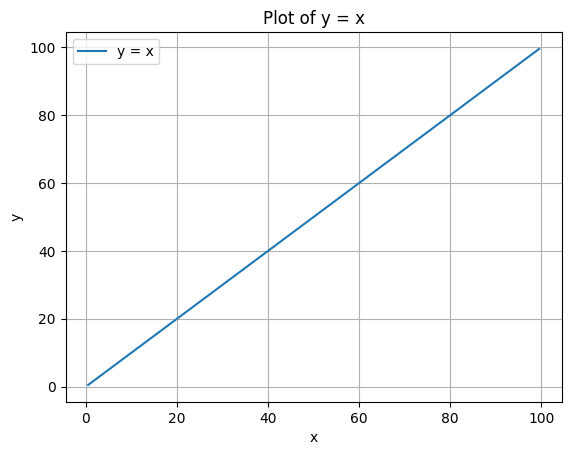

```python
# y1 = x

y1 = x
plt.plot(x, y1, label='y = x')
plt.xlabel('x')
plt.ylabel('y')
plt.title('Plot of y = x')
plt.legend()
plt.grid()
plt.show()
```

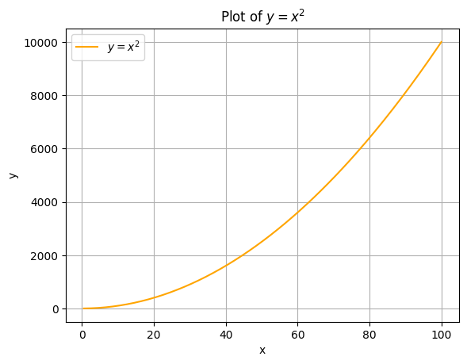

```python
# y2 = x^2
y2 = x**2
plt.plot(x, y2, label='$y = x^2$', color='orange')
plt.xlabel('x')
plt.ylabel('y')
plt.title('Plot of $y = x^2$')
plt.legend()
plt.grid()
plt.show()
```

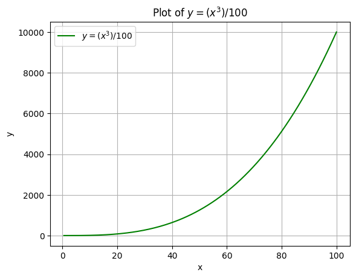

```python
# y3 = (x^3)/100
y3 = (x**3) / 100
plt.plot(x, y3, label='$y = (x^3)/100$', color='green')
plt.xlabel('x')
plt.ylabel('y')
plt.title('Plot of $y = (x^3)/100$')
plt.legend()
plt.grid()
plt.show()
```

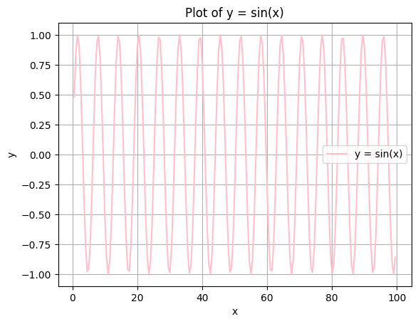

```python
#y4 = sin(x)
y4 = np.sin(x)
plt.plot(x, y4, label='y = sin(x)', color='pink')
plt.xlabel('x')
plt.ylabel('y')
plt.title('Plot of y = sin(x)')
plt.legend()
plt.grid()
plt.show()
```

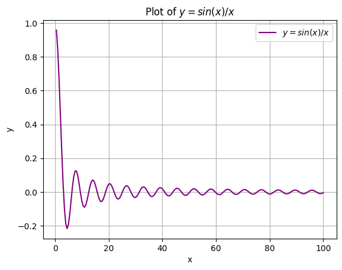

```python
# y5 = sin(x)/x
y5 = np.sin(x) / x
plt.plot(x, y5, label='$y = sin(x)/x$', color='purple')
plt.xlabel('x')
plt.ylabel('y')
plt.title('Plot of $y = sin(x)/x$')
plt.legend()
plt.grid()
plt.show()
```

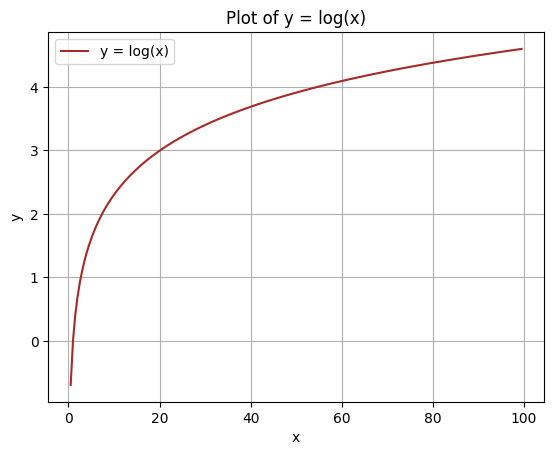

```python
#y6 = log(x)
y6 = np.log(x)
plt.plot(x, y6, label='y = log(x)', color='brown')
plt.xlabel('x')
plt.ylabel('y')
plt.title('Plot of y = log(x)')
plt.legend()
plt.grid()
plt.show()
```

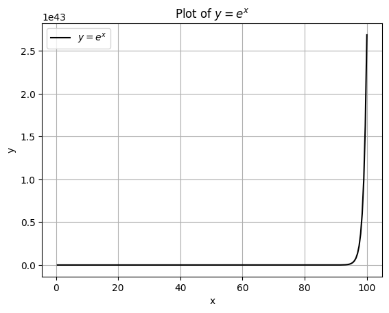

```python
# y7 = e^x
y7 = np.exp(x)
plt.plot(x, y7, label='$y = e^x$', color='black')
plt.xlabel('x')
plt.ylabel('y')
plt.title('Plot of $y = e^x$')
plt.legend()
plt.grid()
plt.show()
```

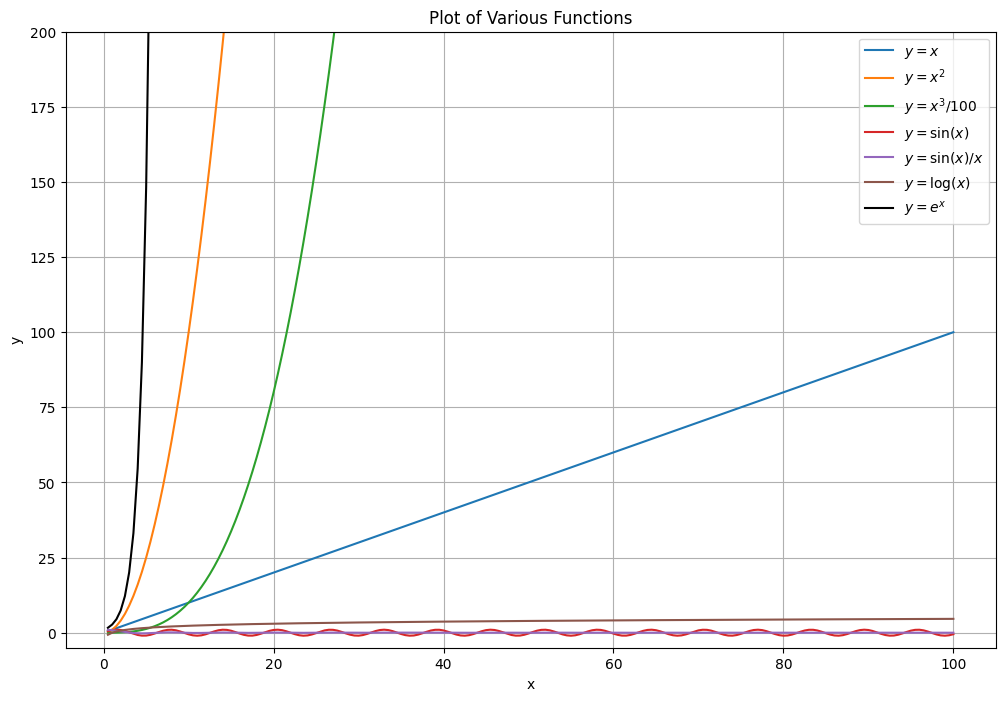

```python
# Create a single plot for all functions
y1 = x
y2 = x**2
y3 = x**3 / 100
y4 = np.sin(x)
y5 = np.sin(x) / x
y6 = np.log(x)
y7 = np.exp(x)

plt.figure(figsize=(12, 8))
plt.plot(x, y1, label='$y=x$')
plt.plot(x, y2, label='$y=x^2$')
plt.plot(x, y3, label='$y=x^3/100$')
plt.plot(x, y4, label='$y=\sin(x)$')
plt.plot(x, y5, label='$y=\sin(x)/x$')
plt.plot(x, y6, label='$y=\log(x)$')
plt.plot(x, y7, label='$y=e^x$', color='black')
plt.xlabel("x")
plt.ylabel("y")
plt.title("Plot of Various Functions")
plt.legend()
plt.grid(True)
plt.ylim(-5, 200)
plt.show()
```

10. Using numpy generate a matrix of size 20X5 containing random numbers drawn uniformly from the range of 1 to 2. Using Pandas create a dataframe out of this matrix. Name the columns of the dataframe as “a”, “b”, “c”, “d”, “e”. Find the column with the highest standard deviation. Find the row with the lowest mean.

```python
data = np.random.uniform(1, 2, size=(20, 5))
df = pd.DataFrame(data, columns=['a', 'b', 'c', 'd', 'e'])
print(df.head())
print("\n")
std_dev = df.std().idxmax()
lowest_mean_row = df.mean(axis=1).idxmin()
print(f"Column with highest standard deviation: {std_dev}")
print(f"Row with lowest mean: {lowest_mean_row}")
# --- IGNORE ---
```

```
          a         b         c         d         e
0  1.948729  1.960872  1.826523  1.689963  1.658843
1  1.547202  1.339767  1.341342  1.405850  1.977264
2  1.821386  1.700372  1.863258  1.726819  1.408071
3  1.276309  1.345264  1.020317  1.319466  1.106445
4  1.640735  1.987025  1.133210  1.047426  1.620801


Column with highest standard deviation: c
Row with lowest mean: 3
```

11. Add a new column to the dataframe called “f” which is the sum of the columns “a”, “b”, “c”, “d”, “e”. Create another column called “g”. The value in the column “g” should be “LT8” if the value in the column “f” is less than 8 and “GT8” otherwise. Find the number of rows in the dataframe where the value in the column “g” is “LT8”. Find the standard deviation of the column “f” for the rows where the value in the column “g” is “LT8” and “GT8” respectively.

```python
df['f'] = df[['a', 'b', 'c', 'd', 'e']].sum(axis=1)
df["g"] = np.where(df["f"] < 8, "LT8", "GT8")
print(df.head())
print("\n")
LT8_count = (df["g"] == "LT8").sum()
std_dev_LT8 = df[df["g"] == "LT8"]["f"].std()
std_dev_GT8 = df[df["g"] == "GT8"]["f"].std()
print(f"Number of rows where g is LT8: {LT8_count}")
print(f"Standard deviation of f for LT8: {std_dev_LT8}")
print(f"Standard deviation of f for GT8: {std_dev_GT8}")
```

```
          a         b         c         d         e         f    g
0  1.948729  1.960872  1.826523  1.689963  1.658843  9.084929  GT8
1  1.547202  1.339767  1.341342  1.405850  1.977264  7.611425  LT8
2  1.821386  1.700372  1.863258  1.726819  1.408071  8.519906  GT8
3  1.276309  1.345264  1.020317  1.319466  1.106445  6.067801  LT8
4  1.640735  1.987025  1.133210  1.047426  1.620801  7.429197  LT8


Number of rows where g is LT8: 16
Standard deviation of f for LT8: 0.4887816438455369
Standard deviation of f for GT8: 0.4349067679470779
```

12. Write a small piece of code to explain broadcasting in numpy.

```python
M = np.ones((2,3))
a = np.arange(3)
print(M)
print(a)
# a.shape = (3, 1)
# b.shape = (3,)
M + a # Broadcasting example
```

```
[[1. 1. 1.]
 [1. 1. 1.]]
[0 1 2]
```

```
array([[1., 2., 3.],
       [1., 2., 3.]])
```

13. Write a function to compute the argmin of a numpy array. The function should take a numpy array as input and return the index of the minimum element. You can use the np.argmin function to verify your solution.

```python
def argmin(arr):
    """Compute the index of the minimum element in a numpy array."""
    min_value = arr[0]
    min_index = 0
    for i in range(1,len(arr)):
        if arr[i] < min_value:
            min_value = arr[i]
            min_index = i

    return min_index

# Example usage
arr = np.array([3, 1, 4, 1, 5, 9, 2, 6, 5])
index_of_min = argmin(arr)
print(f"The index of the minimum element in the array is: {index_of_min}")
# Verification using np.argmin
print(f"Verification using np.argmin: {np.argmin(arr)}")
```

```
The index of the minimum element in the array is: 1
Verification using np.argmin: 1
```